# Homework 11

## Question 1: Implementing K-means

K-means is a relatively simple algorithm that we can write ourselves. For Questions 1 and 2, do not use an existing function that performs K-means directly.

Generate 10 observations with two independent standard normal coordinates. Set a random seed and report it. Randomly assign the observations to $K=2$ clusters, making sure neither cluster is empty. Let $C(i)$ denote the cluster assigned to observation $x_i$, and let $m_k$ denote the mean of cluster $k$.

1. Perform one iteration: calculate the cluster means, then assign each observation to its closest mean using Euclidean distance. Report the means and updated assignments, and plot the observations colored by their updated assignments.
2. Write a function that repeats these two steps until the assignments stop changing or a specified maximum number of iterations is reached. Your function should work for a data matrix with any number of variables and a chosen number of clusters $K$. Start from a nonempty assignment to each cluster; if a cluster becomes empty during iteration, keep its previous mean. Recalculate the cluster means from the final assignments before returning them. Return the final assignments, cluster means, and within-cluster sum of squares,

   $$\sum_{k=1}^K\sum_{i:\,C(i)=k}\lVert x_i-m_k\rVert^2.$$
3. Apply your function to the same 10 observations from two different random initial assignments. Report the final plots, cluster means, and within-cluster sums of squares. Do the two runs produce the same grouping and objective value? Explain your findings.

### Solution:

#### a.

I used random seed 432 to generate the observations and initial cluster assignments.

```r
set.seed(432)

x = matrix(rnorm(20), ncol = 2)
colnames(x) = c("x1", "x2")
C = sample(rep(1:2, each = 5))

m = rbind(
  colMeans(x[C == 1, , drop = FALSE]),
  colMeans(x[C == 2, , drop = FALSE])
)
rownames(m) = c("Cluster 1", "Cluster 2")

cat("Initial cluster means:\n")
```

```
Initial cluster means:
```

```r
round(m, 3)
```

```
             x1     x2
Cluster 1 0.191 -0.836
Cluster 2 0.093  0.222
```

```r
d = sapply(1:2, function(k) {
  rowSums(sweep(x, 2, m[k, ], "-")^2)
})

C_new = max.col(-d, ties.method = "first")

data.frame(
  Observation = 1:nrow(x),
  Initial = C,
  Updated = C_new
)
```

```
   Observation Initial Updated
1            1       2       2
2            2       2       2
3            3       1       1
4            4       1       1
5            5       2       2
6            6       1       1
7            7       2       2
8            8       1       1
9            9       2       1
10          10       1       1
```

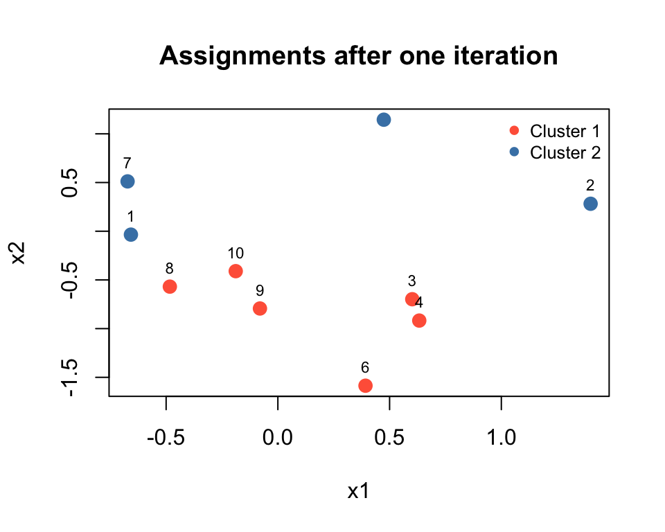

```r
cols = c("tomato", "steelblue")

plot(x, col = cols[C_new], pch = 19, cex = 1.3,
     xlab = "x1", ylab = "x2",
     main = "Assignments after one iteration")
text(x, labels = 1:nrow(x), pos = 3, cex = 0.7)
legend("topright", legend = c("Cluster 1", "Cluster 2"),
       col = cols, pch = 19, bty = "n", cex = 0.8)
```

#### b.

```r
my_kmeans = function(x, K, initial, max_iter = 100) {
  x = as.matrix(x)
  n = nrow(x)

  if (K < 1 || K > n ||
      length(initial) != n ||
      !setequal(unique(initial), seq_len(K))) {
    stop("Initial assignments must contain all K clusters.")
  }

  C = as.integer(initial)
  m = matrix(NA_real_, nrow = K, ncol = ncol(x))
  colnames(m) = colnames(x)
  rownames(m) = paste("Cluster", 1:K)

  for (k in 1:K) {
    m[k, ] = colMeans(x[C == k, , drop = FALSE])
  }

  for (iter in seq_len(max_iter)) {
    d = sapply(1:K, function(k) {
      rowSums(sweep(x, 2, m[k, ], "-")^2)
    })
    d = matrix(d, nrow = n, ncol = K)

    C_new = max.col(-d, ties.method = "first")

    if (all(C_new == C)) break

    C = C_new

    for (k in 1:K) {
      if (any(C == k)) {
        m[k, ] = colMeans(x[C == k, , drop = FALSE])
      }
    }
  }

  for (k in 1:K) {
    if (any(C == k)) {
      m[k, ] = colMeans(x[C == k, , drop = FALSE])
    }
  }

  wcss = sum(rowSums((x - m[C, , drop = FALSE])^2))

  list(cluster = C, means = m, wcss = wcss)
}
```

#### c.

I used seed 433 for the two random initial assignments.

```r
set.seed(433)

start1 = sample(rep(1:2, each = 5))
start2 = sample(rep(1:2, each = 5))

while (all(start1 == start2) || all(start1 == 3 - start2)) {
  start2 = sample(rep(1:2, each = 5))
}

rbind(Start1 = start1, Start2 = start2)
```

```
       [,1] [,2] [,3] [,4] [,5] [,6] [,7] [,8] [,9] [,10]
Start1    2    1    1    1    2    2    2    1    1     2
Start2    2    2    1    2    1    2    1    2    1     1
```

```r
fit1 = my_kmeans(x, K = 2, initial = start1)
fit2 = my_kmeans(x, K = 2, initial = start2)

cat("Run 1 cluster means:\n")
```

```
Run 1 cluster means:
```

```r
print(round(fit1$means, 3))
```

```
              x1     x2
Cluster 1  0.589 -0.743
Cluster 2 -0.306  0.129
```

```r
cat("Run 1 WCSS:", round(fit1$wcss, 3), "\n\n")
```

```
Run 1 WCSS: 5.837
```

```r
cat("Run 2 cluster means:\n")
```

```
Run 2 cluster means:
```

```r
print(round(fit2$means, 3))
```

```
              x1     x2
Cluster 1 -0.021  0.154
Cluster 2  0.387 -0.999
```

```r
cat("Run 2 WCSS:", round(fit2$wcss, 3))
```

```
Run 2 WCSS: 6.146
```

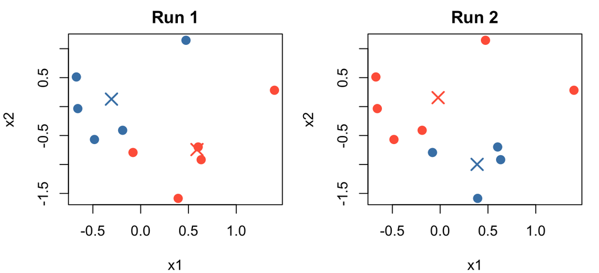

```r
fits = list(fit1, fit2)
cols = c("tomato", "steelblue")

oldpar = par(mfrow = c(1, 2), mar = c(4, 4, 2, 1))

for (j in 1:2) {
  fit = fits[[j]]

  plot(x, col = cols[fit$cluster], pch = 19, cex = 1.3,
       xlab = "x1", ylab = "x2",
       main = paste("Run", j))

  points(fit$means, pch = 4, cex = 1.8,
         lwd = 2, col = cols)
}
```

```r
par(oldpar)
```

The two runs produced different groupings and had different within-cluster sums of squares. K-means can depend on its initial assignments because it may converge to different local minima. This is why using multiple random starts and choosing the solution with the smallest within-cluster sum of squares is useful.

## Question 2: Image color compression

Pick your favorite color image and use your K-means function from Question 1 to cluster its pixels. For computational efficiency, resize the image to no more than $200\times200$ pixels and use its three RGB color channels.

1. Plot the original image and report its dimensions. Transform it into a data matrix with one observation per pixel and three variables: red, green, and blue. Report the dimensions of this matrix.
2. For $K=2,3,5,10$, apply your function to the pixel data. Report the cluster means and within-cluster sum of squares for each $K$. Reconstruct and plot each compressed image by replacing every pixel with its assigned cluster mean. Use the same RGB scale for all fits.
3. Which value of $K$ would you choose for this image? Briefly justify your choice using the reconstructed images and the within-cluster sums of squares.

### Solution:

#### a.

```r
library(magick)
img_file = image_read("rose:")
img_file = image_resize(img_file, "200x200>")

rgb_raw = image_data(img_file, channels = "rgb")
img = aperm(
  array(as.integer(rgb_raw) / 255, dim = dim(rgb_raw)),
  c(3, 2, 1)
)

cat("Image dimensions:", dim(img), "\n")
```

```
Image dimensions: 46 70 3
```

```r
img_expand = apply(img, 3, c)
colnames(img_expand) = c("Red", "Green", "Blue")

cat("Pixel data dimensions:", dim(img_expand), "\n")
```

```
Pixel data dimensions: 3220 3
```

[figure not shown]

```r
par(mar = rep(0, 4))
plot.new()
plot.window(xlim = c(0, 1), ylim = c(0, 1),
            xaxs = "i", yaxs = "i")
rasterImage(img, 0, 0, 1, 1)
```

#### b.

```r
set.seed(432)

Ks = c(2, 3, 5, 10)
fits = list()

for (K in Ks) {
  initial = sample(rep(1:K, length.out = nrow(img_expand)))

  fit = my_kmeans(img_expand, K, initial, max_iter = 100)
  fits[[as.character(K)]] = fit

  cat("\nK =", K, "\n")
  cat("Cluster means:\n")
  print(round(fit$means, 3))
  cat("Within-cluster sum of squares:",
      round(fit$wcss, 3), "\n")
}
```

```
K = 2
Cluster means:
            Red Green  Blue
Cluster 1 0.288 0.280 0.286
Cluster 2 0.788 0.811 0.793
Within-cluster sum of squares: 173.571

K = 3
Cluster means:
            Red Green  Blue
Cluster 1 0.472 0.459 0.475
Cluster 2 0.235 0.232 0.236
Cluster 3 0.853 0.875 0.844
Within-cluster sum of squares: 100.971

K = 5
Cluster means:
            Red Green  Blue
Cluster 1 0.382 0.382 0.389
Cluster 2 0.693 0.593 0.494
Cluster 3 0.372 0.575 0.799
Cluster 4 0.222 0.218 0.222
Cluster 5 0.880 0.900 0.889
Within-cluster sum of squares: 67.027

K = 10
Cluster means:
             Red Green  Blue
Cluster 1  0.888 0.566 0.251
Cluster 2  0.924 0.944 0.928
Cluster 3  0.431 0.416 0.397
Cluster 4  0.479 0.765 0.924
Cluster 5  0.188 0.187 0.191
Cluster 6  0.578 0.557 0.542
Cluster 7  0.253 0.242 0.242
Cluster 8  0.306 0.323 0.341
Cluster 9  0.279 0.423 0.696
Cluster 10 0.800 0.766 0.736
Within-cluster sum of squares: 37.453
```

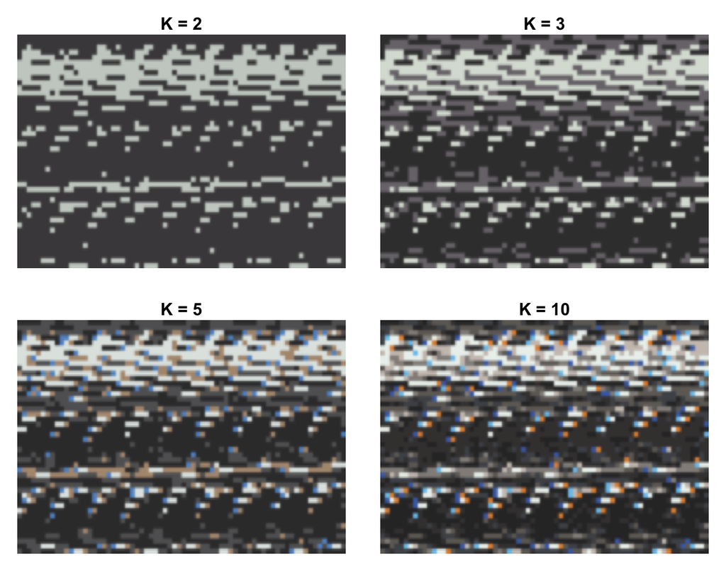

```r
oldpar = par(mfrow = c(2, 2), mar = c(1, 1, 2, 1))

for (K in Ks) {
  fit = fits[[as.character(K)]]

  new_img_expand = fit$means[fit$cluster, , drop = FALSE]
  new_img = img

  for (j in 1:3) {
    new_img[, , j] = matrix(
      new_img_expand[, j],
      nrow = dim(img)[1],
      ncol = dim(img)[2]
    )
  }

  plot.new()
  plot.window(xlim = c(0, 1), ylim = c(0, 1),
              xaxs = "i", yaxs = "i")
  rasterImage(new_img, 0, 0, 1, 1)
  title(main = paste("K =", K), line = 0.3)
}
```

```r
par(oldpar)
```

## Question 3: Hierarchical clustering of cars

The file `data/mtcars.csv` contains 11 numerical variables for 32 cars, including fuel economy, horsepower, and weight. The `car` column gives the model names; use it to label observations, not as a clustering variable. You may use existing hierarchical clustering functions for this question.

1. Standardize each numerical variable to have mean 0 and standard deviation 1. Using Euclidean distance, perform hierarchical clustering with single, complete, and average linkage. Plot the three dendrograms with the car names and compare the results.
2. Choose one linkage method and a number of clusters that you consider reasonable. Report the cluster memberships and a table of cluster means on the original variable scales. Describe the main characteristics of the groups and explain your choice using the dendrogram and table. Briefly explain why standardizing the variables matters for this analysis.

### Solution:

#### a.

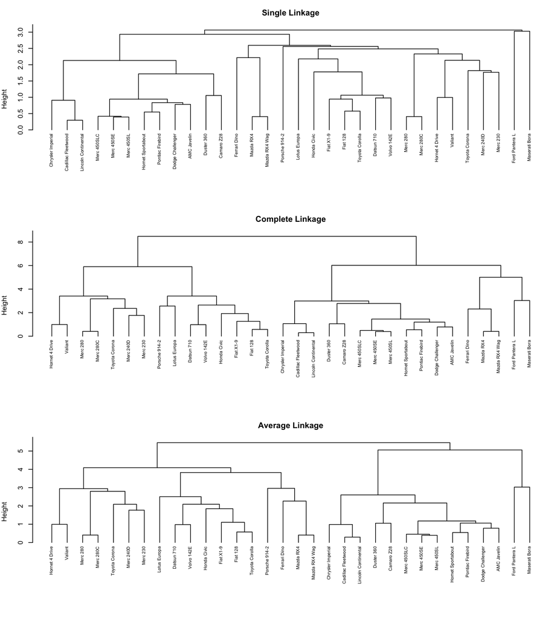

```r
cars = read.csv("data/mtcars.csv")

x = cars[, names(cars) != "car"]
rownames(x) = cars$car

x_scaled = scale(x)
d = dist(x_scaled, method = "euclidean")

hc_single = hclust(d, method = "single")
hc_complete = hclust(d, method = "complete")
hc_average = hclust(d, method = "average")

oldpar = par(mfrow = c(3, 1), mar = c(4, 4, 3, 1))

plot(hc_single, hang = -1, cex = 0.65,
     main = "Single Linkage", xlab = "", sub = "")

plot(hc_complete, hang = -1, cex = 0.65,
     main = "Complete Linkage", xlab = "", sub = "")

plot(hc_average, hang = -1, cex = 0.65,
     main = "Average Linkage", xlab = "", sub = "")
```

```r
par(oldpar)
```

The three linkage methods produce different clustering patterns. Single linkage tends to form chains by adding observations based on their closest neighbors, making the groups less distinct. Complete linkage produces more compact and clearly separated groups because it considers the largest distance between observations in different clusters. Average linkage provides a balance between the two methods by using the average pairwise distance. Overall, complete linkage appears more useful for identifying distinct groups of cars.

#### b.

I chose complete linkage with $K=3$ clusters because it provides a reasonable separation of the cars while keeping the number of groups small enough to interpret.

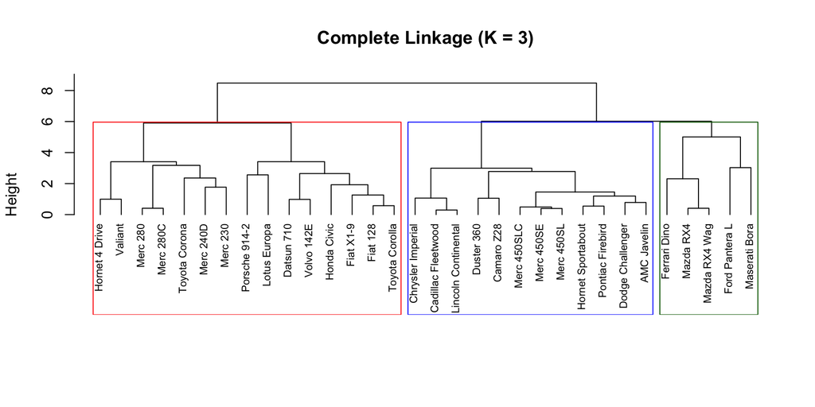

```r
clusters = cutree(hc_complete, k = 3)

plot(hc_complete, hang = -1, cex = 0.7,
     main = "Complete Linkage (K = 3)",
     xlab = "", sub = "")

rect.hclust(hc_complete, k = 3,
            border = c("red", "blue", "darkgreen"))
```

```r
members = data.frame(
  Car = cars$car,
  Cluster = clusters
)

members = members[order(members$Cluster, members$Car), ]
rownames(members) = NULL

knitr::kable(members, caption = "Cluster Memberships")
```

Cluster Memberships

| Car | Cluster |
| --- | --- |
| Ferrari Dino | 1 |
| Ford Pantera L | 1 |
| Maserati Bora | 1 |
| Mazda RX4 | 1 |
| Mazda RX4 Wag | 1 |
| Datsun 710 | 2 |
| Fiat 128 | 2 |
| Fiat X1-9 | 2 |
| Honda Civic | 2 |
| Hornet 4 Drive | 2 |
| Lotus Europa | 2 |
| Merc 230 | 2 |
| Merc 240D | 2 |
| Merc 280 | 2 |
| Merc 280C | 2 |
| Porsche 914-2 | 2 |
| Toyota Corolla | 2 |
| Toyota Corona | 2 |
| Valiant | 2 |
| Volvo 142E | 2 |
| AMC Javelin | 3 |
| Cadillac Fleetwood | 3 |
| Camaro Z28 | 3 |
| Chrysler Imperial | 3 |
| Dodge Challenger | 3 |
| Duster 360 | 3 |
| Hornet Sportabout | 3 |
| Lincoln Continental | 3 |
| Merc 450SE | 3 |
| Merc 450SL | 3 |
| Merc 450SLC | 3 |
| Pontiac Firebird | 3 |

```r
cluster_means = aggregate(x, by = list(Cluster = clusters),
                          FUN = mean)

cluster_means[-1] = round(cluster_means[-1], 2)

knitr::kable(cluster_means,
             caption = "Cluster Means (Original Scales)")
```

Cluster Means (Original Scales)

| Cluster | mpg | cyl | disp | hp | drat | wt | qsec | vs | am | gear | carb |
| --- | --- | --- | --- | --- | --- | --- | --- | --- | --- | --- | --- |
| 1 | 18.50 | 6.80 | 223.40 | 198.80 | 3.84 | 3.00 | 15.62 | 0.00 | 1.00 | 4.60 | 5.20 |
| 2 | 24.65 | 4.53 | 131.65 | 91.33 | 3.90 | 2.58 | 19.16 | 0.93 | 0.53 | 3.93 | 1.80 |
| 3 | 15.05 | 8.00 | 357.62 | 194.17 | 3.12 | 4.10 | 17.14 | 0.00 | 0.00 | 3.00 | 3.08 |

The cluster means show differences in fuel economy, engine size, horsepower, and weight. Cars with higher fuel economy generally have smaller engines, lower horsepower, and lighter weights, while heavier cars with larger engines tend to have lower fuel economy. The three-cluster solution helps separate cars with different performance and size characteristics.

I chose complete linkage because the dendrogram provides reasonably distinct groups, and the cluster means help explain how these groups differ.

Standardizing the variables is important because they are measured on different scales. For example, displacement has much larger numerical values than variables such as the number of cylinders or gears. Without standardization, variables with larger scales would dominate the Euclidean distances and have a greater influence on the clustering.